# Assignment_3_Part_2

For this assignment, you will be working with the [Titanic Data Set from Kaggle](https://www.kaggle.com/c/titanic). This is a very famous data set and very often is a student's first step in Data Analytics!

The Dataset has been given to you in D2L. You need to download the .csv file from your assignment folder. The above link is just for a reference story about the data. The second part of assignment 3 has 50 points.

## Exercise

1- For this assignment, you need to perform explorotary data analysis and answer at least three hypotheses based on the dataset. You may need to use your knowledge of statiscts to analyze this data.

Here are three possible hypotheses that you can define for this dataset (you can define your own hypotheses as well):

- Determine if the survival rate is associated to the class of passenger
- Determine if the survival rate is associated to the gender
- Determine the survival rate is associated to the age

2- For each hypothesis, you need to make at least one plot.

3- Write a summary of your findings in one page (e.g., summary statistics, plots) and submit the pdf file. Therefore, for part 2 of your assignment, you need to submit one jupyter notebook file and one pdf file.

### Github & D2L Submissions

Please create a **public** github repo and submit your answers on both **public github** and on **D2L**. Please include the link to your github repo in your submission.

**Please follow the below guidelines regarding your github repository:**

The folder structure of your github account should be as followed:

```
├── src                     # Source files (your python code)
├── data                    # Data related to the project (titanic.csv)
├── result                  # Result of the project (e.g., plots, reports)
└── doc                     # Documentation files (additional documentations)
```

You must add **README.md** file to the root repository of your GitHub and explain all the directories in your GitHub repo in README file. Please look at this link as a [reference](https://help.github.com/en/github/creating-cloning-and-archiving-repositories/about-readmes) on how to write the README file.

This will be your first end to end data analysis project. For this assignment, you will be graded on you overall analysis, your final report and the structure of your github repo.

```python
import pandas as pd
import numpy as np
import seaborn as sns
import matplotlib.pyplot as plt
titanic=pd.read_csv("titanic.csv")
titanic.head()
```

|  | PassengerId | Survived | Pclass | Name | Sex | Age | SibSp | Parch | Ticket | Fare | Cabin | Embarked |
| --- | --- | --- | --- | --- | --- | --- | --- | --- | --- | --- | --- | --- |
| 0 | 1 | 0 | 3 | Braund, Mr. Owen Harris | male | 22.0 | 1 | 0 | A/5 21171 | 7.2500 | NaN | S |
| 1 | 2 | 1 | 1 | Cumings, Mrs. John Bradley (Florence Briggs Th... | female | 38.0 | 1 | 0 | PC 17599 | 71.2833 | C85 | C |
| 2 | 3 | 1 | 3 | Heikkinen, Miss. Laina | female | 26.0 | 0 | 0 | STON/O2. 3101282 | 7.9250 | NaN | S |
| 3 | 4 | 1 | 1 | Futrelle, Mrs. Jacques Heath (Lily May Peel) | female | 35.0 | 1 | 0 | 113803 | 53.1000 | C123 | S |
| 4 | 5 | 0 | 3 | Allen, Mr. William Henry | male | 35.0 | 0 | 0 | 373450 | 8.0500 | NaN | S |

```python
titanic.describe()
```

|  | PassengerId | Survived | Pclass | Age | SibSp | Parch | Fare |
| --- | --- | --- | --- | --- | --- | --- | --- |
| count | 891.000000 | 891.000000 | 891.000000 | 714.000000 | 891.000000 | 891.000000 | 891.000000 |
| mean | 446.000000 | 0.383838 | 2.308642 | 29.699118 | 0.523008 | 0.381594 | 32.204208 |
| std | 257.353842 | 0.486592 | 0.836071 | 14.526497 | 1.102743 | 0.806057 | 49.693429 |
| min | 1.000000 | 0.000000 | 1.000000 | 0.420000 | 0.000000 | 0.000000 | 0.000000 |
| 25% | 223.500000 | 0.000000 | 2.000000 | 20.125000 | 0.000000 | 0.000000 | 7.910400 |
| 50% | 446.000000 | 0.000000 | 3.000000 | 28.000000 | 0.000000 | 0.000000 | 14.454200 |
| 75% | 668.500000 | 1.000000 | 3.000000 | 38.000000 | 1.000000 | 0.000000 | 31.000000 |
| max | 891.000000 | 1.000000 | 3.000000 | 80.000000 | 8.000000 | 6.000000 | 512.329200 |

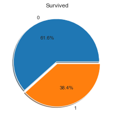

```python
plt.pie(titanic['Survived'].value_counts()
        ,labels = titanic['Survived'].value_counts().index
        ,autopct='%1.1f%%'
        ,shadow=True
        ,explode = (0.05, 0.0)
       )
plt.title('Survived')
plt.show()
```

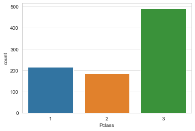

```python
sns.countplot(x='Pclass',data=titanic)
```

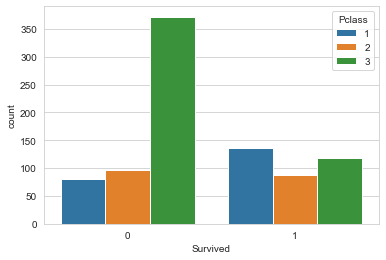

```python
sns.set_style('whitegrid')
sns.countplot(x=titanic['Survived'],hue=titanic['Pclass'],data=titanic)
```

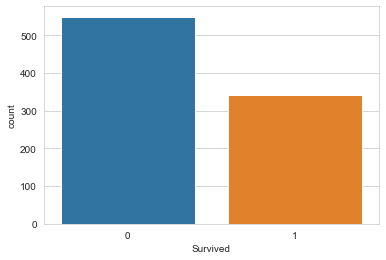

```python
sns.countplot(x='Survived',data=titanic)
```

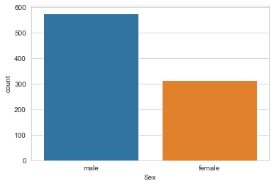

```python
sns.countplot(x='Sex',data=titanic)
```

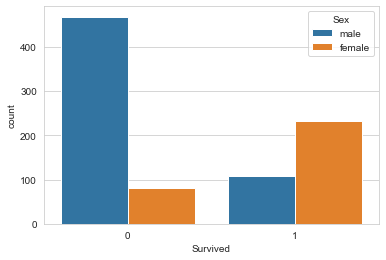

```python
sns.set_style('whitegrid')
sns.countplot(x=titanic['Survived'],hue=titanic['Sex'],data=titanic)
```

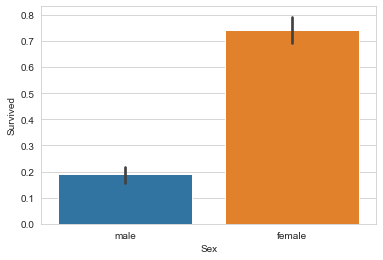

```python
sns.barplot(data=titanic, x='Sex', y='Survived')
plt.show()
```

[output not shown]

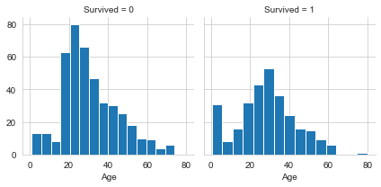

```python
age = sns.FacetGrid(titanic, col = 'Survived')
age.map(plt.hist, 'Age', bins = 15)
plt.show
```